# Risk Factor Analysis

## Outcome Variable

**Outcome Variable:** whz

## Predictor Variables

**Intervention Variable:** country

**Adjustment Set:**

unadjusted

## Stratifying Variables

The analysis was stratified on these variable(s):

- agecat

## Data Summary

| agecat | country | n_cell | n |
| --- | --- | --- | --- |
| Birth | BANGLADESH | 16692 | 56639 |
| Birth | BELARUS | 13824 | 56639 |
| Birth | BRAZIL | 294 | 56639 |
| Birth | GAMBIA | 1423 | 56639 |
| Birth | GUATEMALA | 756 | 56639 |
| Birth | GUINEA-BISSAU | 0 | 56639 |
| Birth | INDIA | 6993 | 56639 |
| Birth | MALAWI | 0 | 56639 |
| Birth | NEPAL | 168 | 56639 |
| Birth | PAKISTAN | 7 | 56639 |
| Birth | PERU | 291 | 56639 |
| Birth | PHILIPPINES | 2899 | 56639 |
| Birth | SOUTH AFRICA | 258 | 56639 |
| Birth | TANZANIA, UNITED REPUBLIC OF | 118 | 56639 |
| Birth | ZIMBABWE | 12916 | 56639 |
| 6 months | BANGLADESH | 23934 | 70656 |
| 6 months | BELARUS | 15757 | 70656 |
| 6 months | BRAZIL | 317 | 70656 |
| 6 months | GAMBIA | 2089 | 70656 |
| 6 months | GUATEMALA | 1262 | 70656 |
| 6 months | GUINEA-BISSAU | 849 | 70656 |
| 6 months | INDIA | 9576 | 70656 |
| 6 months | MALAWI | 839 | 70656 |
| 6 months | NEPAL | 799 | 70656 |
| 6 months | PAKISTAN | 611 | 70656 |
| 6 months | PERU | 1124 | 70656 |
| 6 months | PHILIPPINES | 2706 | 70656 |
| 6 months | SOUTH AFRICA | 254 | 70656 |
| 6 months | TANZANIA, UNITED REPUBLIC OF | 2275 | 70656 |
| 6 months | ZIMBABWE | 8264 | 70656 |
| 24 months | BANGLADESH | 15313 | 34524 |
| 24 months | BELARUS | 3971 | 34524 |
| 24 months | BRAZIL | 169 | 34524 |
| 24 months | GAMBIA | 1726 | 34524 |
| 24 months | GUATEMALA | 1082 | 34524 |
| 24 months | GUINEA-BISSAU | 551 | 34524 |
| 24 months | INDIA | 6299 | 34524 |
| 24 months | MALAWI | 563 | 34524 |
| 24 months | NEPAL | 726 | 34524 |
| 24 months | PAKISTAN | 0 | 34524 |
| 24 months | PERU | 794 | 34524 |
| 24 months | PHILIPPINES | 2449 | 34524 |
| 24 months | SOUTH AFRICA | 238 | 34524 |
| 24 months | TANZANIA, UNITED REPUBLIC OF | 220 | 34524 |
| 24 months | ZIMBABWE | 423 | 34524 |

The following strata were considered:

- agecat: 24 months
- agecat: 6 months
- agecat: Birth

### Dropped Strata

Some strata were dropped due to rare outcomes:

- agecat: Birth
- agecat: 24 months

## Methods Detail

We’re interested in the causal parameters $E[Y_a]$ for all values of $a \in \mathcal{A}$. These parameters represent the mean outcome if, possibly contrary to fact, we intervened to set all units to have $A=a$. Under the randomization and positivity assumptions, these are identified by the statistical parameters $\psi_a=E_W[E_{Y|A,W}(Y|A=a,W)]$. In addition, we’re interested in the mean of $Y$, $E[Y]$ under no intervention (the observed mean). We will estimate these parameters by using SuperLearner to fit the relevant likelihood factors – $E_{Y|A,W}(Y|A=a,W)$ and $p(A=a|W)$, and then updating our likelihood fit using a joint TMLE.

For unadjusted analyses ($W=\{\}$), initial likelihoods were estimated using Lrnr_glm to estimate the simple $E(Y|A)$ and Lrnr_mean to estimate $p(A)$. For adjusted analyses, a small library containing Lrnr_glmnet, Lrnr_xgboost, and Lrnr_mean was used.

Having estimated these parameters, we will then use the delta method to estimate relative risks and attributable risks relative to a prespecified baseline level of $A$.

# Results Detail

## Results Plots

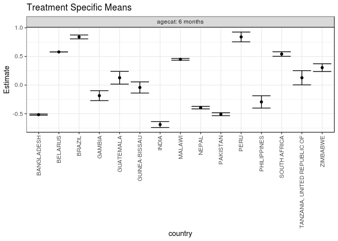

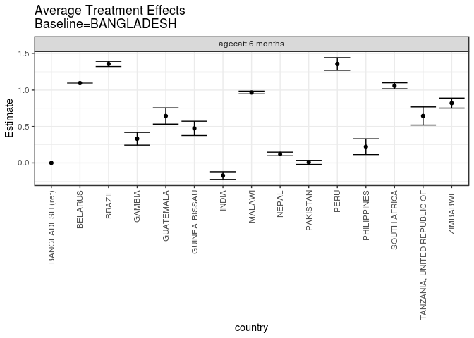

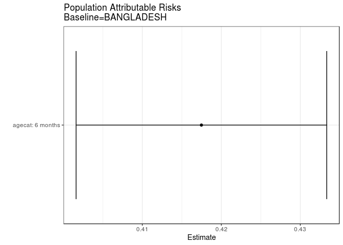

## Results Table

### Parameter: TSM

| agecat | intervention_level | baseline_level | estimate | ci_lower | ci_upper |
| --- | --- | --- | --- | --- | --- |
| 6 months | BANGLADESH | NA | -0.5162074 | -0.5268383 | -0.5055765 |
| 6 months | BELARUS | NA | 0.5789633 | 0.5786880 | 0.5792386 |
| 6 months | BRAZIL | NA | 0.8413249 | 0.8070045 | 0.8756454 |
| 6 months | GAMBIA | NA | -0.1846223 | -0.2713066 | -0.0979380 |
| 6 months | GUATEMALA | NA | 0.1281933 | 0.0170502 | 0.2393365 |
| 6 months | GUINEA-BISSAU | NA | -0.0418080 | -0.1393310 | 0.0557150 |
| 6 months | INDIA | NA | -0.6892810 | -0.7407603 | -0.6378018 |
| 6 months | MALAWI | NA | 0.4499285 | 0.4348317 | 0.4650253 |
| 6 months | NEPAL | NA | -0.3933605 | -0.4155686 | -0.3711523 |
| 6 months | PAKISTAN | NA | -0.5086170 | -0.5344928 | -0.4827413 |
| 6 months | PERU | NA | 0.8407647 | 0.7549575 | 0.9265719 |
| 6 months | PHILIPPINES | NA | -0.2938433 | -0.4016488 | -0.1860379 |
| 6 months | SOUTH AFRICA | NA | 0.5420735 | 0.5024037 | 0.5817433 |
| 6 months | TANZANIA, UNITED REPUBLIC OF | NA | 0.1282832 | 0.0040999 | 0.2524664 |
| 6 months | ZIMBABWE | NA | 0.3047138 | 0.2368713 | 0.3725564 |

### Parameter: E(Y)

| agecat | intervention_level | baseline_level | estimate | ci_lower | ci_upper |
| --- | --- | --- | --- | --- | --- |
| 6 months | NA | NA | -0.0987239 | -0.1131619 | -0.0842858 |

### Parameter: ATE

| agecat | intervention_level | baseline_level | estimate | ci_lower | ci_upper |
| --- | --- | --- | --- | --- | --- |
| 6 months | BANGLADESH | BANGLADESH | 0.0000000 | 0.0000000 | 0.0000000 |
| 6 months | BELARUS | BANGLADESH | 1.0951707 | 1.0845361 | 1.1058054 |
| 6 months | BRAZIL | BANGLADESH | 1.3575323 | 1.3216157 | 1.3934490 |
| 6 months | GAMBIA | BANGLADESH | 0.3315851 | 0.2442626 | 0.4189076 |
| 6 months | GUATEMALA | BANGLADESH | 0.6444008 | 0.5327538 | 0.7560478 |
| 6 months | GUINEA-BISSAU | BANGLADESH | 0.4743994 | 0.3762901 | 0.5725088 |
| 6 months | INDIA | BANGLADESH | -0.1730736 | -0.2256393 | -0.1205079 |
| 6 months | MALAWI | BANGLADESH | 0.9661359 | 0.9476623 | 0.9846095 |
| 6 months | NEPAL | BANGLADESH | 0.1228470 | 0.0982188 | 0.1474751 |
| 6 months | PAKISTAN | BANGLADESH | 0.0075904 | -0.0203714 | 0.0355522 |
| 6 months | PERU | BANGLADESH | 1.3569721 | 1.2705197 | 1.4434245 |
| 6 months | PHILIPPINES | BANGLADESH | 0.2223641 | 0.1140358 | 0.3306925 |
| 6 months | SOUTH AFRICA | BANGLADESH | 1.0582809 | 1.0172287 | 1.0993331 |
| 6 months | TANZANIA, UNITED REPUBLIC OF | BANGLADESH | 0.6444906 | 0.5198574 | 0.7691237 |
| 6 months | ZIMBABWE | BANGLADESH | 0.8209212 | 0.7522497 | 0.8895928 |

### Parameter: PAR

| agecat | intervention_level | baseline_level | estimate | ci_lower | ci_upper |
| --- | --- | --- | --- | --- | --- |
| 6 months | BANGLADESH | NA | 0.4174835 | 0.4016223 | 0.4333447 |